# PLSiMCpp: An R Package for Partial Linear Single Index Model

This paper describes how the package PLSiMCpp implements the procedures of estimation, inference, and variable selection for partially linear singe-index models in R. The paper first briefly introduces the procedures proposed by (Liang et al. 2010), and illustrates these procedures in details by executing several examples. The package was interfaced with **C++** for implementing sophistical calculations, and may be used for data analysis or grafted for advanced methodological research of PLSiM.

Shunyao Wu (Qingdao University) , Qi Zhang (Qingdao University) , Zhiruo Li (Qingdao University) , Hua Liang (George Washington University)  
2022-09-18

# Introduction

A single-index model $E(Y|Z) =\eta(Z^{\top}\alpha)$, in which the link function $\eta$ is unknown, is perhaps a natural choice to use for exploring the relationship between the response $Y$ and covariates $Z$ when the linear assumption does not hold. Various estimation methods for single-index models (Horowitz 2009) have been proposed (Powell et al. 1989; Duan and Li 1991; Härdle et al. 1993; Ichimura 1993; Horowitz and Härdle 1996). Detailed discussions and illustrations of the usefulness of the SiM can be found in (Horowitz 2009). Although the SiM gain a lot of attentions and become popular in data analysis, the models may not be parsimonious enough to explain the variation of responses via covariates $Z$. Therefore, (Carroll et al. 1997) further generalized the SiM in a linear form with additional covariates $X$, which yields a partially linear single-index model (PLSiM),

$$E(Y|Z,X)=\eta(Z^{\top}\alpha)+X^{\top}\beta.$$

The models cover commonly used semiparametric models. As mentioned, the models reduce to SiM without $X$; when $Z$ is scalar, the models reduce to the partially linear model, $E(Y|Z,X) =\eta(Z) + X^{\top}\beta$ (Speckman 1988). A comprehensive review of partially linear models can be found in (Härdle et al. 2000).

To estimate parameters in PLSiM, (Carroll et al. 1997) proposed the backfitting algorithm. (Yu and Ruppert 2002) proposed the penalized spline estimation procedure. (Xia and Härdle 2006) applied the minimum average variance estimation (MAVE) method, which was originally introduced by (Xia et al. 1999) for dimension reduction. (Liang et al. 2010) proposed the profile least squares approach, which obtains efficient estimators, which can be obtained without using the iterative procedure, and hence greatly reduces the computational burden.

In data analysis, the true model is often unknown; this allows the possibility of selecting an underfitted (or overfitted) model, leading to biased (or inefficient) estimators and predictions. To address this problem, (Tibshirani 1996) introduced the least absolute shrinkage and selection operator (LASSO) to shrink the estimated coefficients of superfluous variables to zero in linear regression models. Subsequently, (Fan and Li 2001) proposed the smoothly clipped absolute deviation (SCAD) approach that not only selects important variables consistently, but also produces parameter estimators as efficient as if the true model were known. (Liang et al. 2010) further applied the profile least squares approach to obtain the SCAD estimators for both parameter vectors $\alpha$ and $\beta$.

Consider the PLSiM:
$$\begin{equation}
Y=\eta(Z^{\top}\alpha)+X^{\top}\beta+\varepsilon,
(\#eq:pls1)
\end{equation}$$
where $Y$ is a response variable, $Z$ and $X$ are $p$-dimensional and $q$-dimensional covariate vectors, respectively, $\alpha=(\alpha_1,\cdots,\alpha_p)^{\top}$, $\beta=(\beta_1,\cdots,\beta_q)^{\top}$, $\eta(\cdot)$ is an unknown differentiable function, $\varepsilon$ is the random error with mean zero and finite variance $\sigma^2$, and $(Z^{\top},X^{\top})^{\top}$ and $\varepsilon$ are independent. In this model, $X$ and $Y$ are linearly correlated, while $Z$ and $Y$ are nonlinearly associated.

This article gives a comprehensive description for how to use the **R** package PLSiMCpp we have developed for implementing the procedure proposed in (Liang et al. 2010). Specifically speaking, we briefly describe the estimation procedure in Section 2, inference in Section 3, variable selection in Section 4, and their implementations in Section 5, where the performance of the penalized profile based procedure is illustrated by simulation studies. Section 6 analyzes two real datasets. Section 7 provides concluding remarks.

# Estimation

After estimating $\alpha$ and $\beta$, they estimated $\eta(u)$ as follows.
$$\hat{\eta}(u)=\hat{\eta}(u,\hat{\zeta}) =
\frac{K_{20}(u,\hat{\zeta})K_{01}(u,\hat{\zeta}) -
K_{10}(u,\hat{\zeta})K_{11}(u,\hat{\zeta})}
{K_{00}(u,\hat{\zeta})K_{20}(u,\hat{\zeta}) - K_{10}^2(u,\hat{\zeta})}.$$

## Initialization

To speed the Newton-Naphson iterative procedure, we need a good initial value, for which we suggest to use the MAVE proposed by (Xia et al. 2002) for generalized single index models. In principle, the true values $\alpha_0$ and $\beta_0$ should be the solution of
$$\begin{equation}
\mathop{\arg\min}_{(\alpha,\beta)}
E[Y-\{\eta(Z^{\top}\alpha)+X^{\top}\beta\}]^2
(\#eq:pls5)
\end{equation}$$
subject to $\alpha^{\top}\alpha=1$. (Xia and Härdle 2006) pointed out that this minimization is equivalent to
$$\begin{equation}
\mathop{\arg\min}_{(\alpha,\beta)}
E_{\theta}\delta^2_{\alpha,\beta}(Z^{\top}\alpha)
\tag{1}
\end{equation}$$
subject to $\alpha^{\top}\alpha=1$, where $\theta=Z^{\top}\alpha$ and $\delta^2_{\alpha, \beta}(\theta) =E\left([Y- \{\eta(Z^{\top}\alpha)+X^{\top}\beta\}]^2|Z^{\top}\alpha=\theta\right)$.

## Bandwidth selection

Bandwidth $h$ plays a critical role in estimation. Package PLSiMCpp provides two options for selecting bandwidth: simple validation and cross validation. The former, also named as holdout validation, partitions the dataset into training set and validation set, and the optimal bandwidth is selected on a basis of the prediction performance (e.g., the smallest mean square error) on the validation set. On the other hand, cross validation partitions the original samples into $k$ equal size subsamples, and performs $k$ trials to select the optimal bandwidth. For each trail, a single subsample is retained as the validation set while the remaining $k-1$ subsamples are treated as training data.

In package PLSiMCpp, the epanechnikov kernel function was adopted for regression. For a sample with covariates $(x,z)$, its response variable could be estimated as follow
$$\tilde{y} = x^{\top}\hat{\beta} + \hat{\eta}^{\top}K$$
where $K=[k(\frac{z^{\top}\hat{\alpha}-\hat{\eta}_1}{h}),...,k(\frac{z^{\top}\hat{\alpha}-\hat{\eta}_n}{h})]^{\top}$, and $k(x/h)=\frac{3}{4}(1-x^2)I(|x|\leq{h})$. Besides selecting parameters, the above formula can be utilized to predicting for new samples.

# Hypothesis Tests

We implement two hypothesis tests on regression parameters and the nonparametric function.

## Testing parametric components

Test whether some elements of $\alpha$ and $\beta$ are zero, that is,
$$H_0: \alpha_{i_1}=\cdots=\alpha_{i_k}=0 \ \mbox{ and } \
\beta_{j_1}=\cdots=\beta_{j_l}=0$$
versus
$$H_1: \mbox{not all }\ \alpha_{i_1},\cdots,\alpha_{i_k} \ \mbox{ and } \
\beta_{j_1}, \cdots,\beta_{j_l} \ \mbox{ are equal to }\ 0.$$

Under $H_0$ and $H_1$, let $\zeta_0=(\alpha_0^{\top},\beta_0^{\top})^{\top}$ and $\zeta_1=(\alpha_1^{\top},\beta_1^{\top})^{\top}$ be the corresponding parameter vectors, and let $\Omega_0$ and $\Omega_1$ be the parameter spaces of $\zeta_0$ and $\zeta_1$, respectively.

## Testing the nonparametric component

A goodness-of-fit test to assess the appropriateness of a proposed parametric model, specifically, a simple linear model under the null hypothesis.
$$\ \ H_{np,0}:\eta(u) = \theta_0+\theta_1u \ \mbox{ versus }
H_{np,1}:\ \eta(u)\ne \theta_0 + \theta_1u \ \mbox{for some } u,$$
where $\theta_0$ and $\theta_1$ are unknown constant parameters.

Under $H_{np,1}$, let $\widehat\alpha$, $\widehat\beta$, and $\widehat{\eta}$ be their corresponding profile least squares and nonparametric estimators of $\alpha$, $\beta$, and $\eta$. Under $H_{np,0}$, we use the same parametric estimators $\widehat\alpha$ and $\widehat\beta$ as those obtained under $H_{np,1}$, while the estimator of $\eta$ is $\tilde{\eta}(u)=\hat\theta_0 + \hat\theta_1 u$, where $\hat\theta_0$ and $\hat\theta_1$ are the ordinary least squares estimator of $\theta_0$ and $\theta_1$, respectively, by fitting $Y_i-X_i^{\top}\widehat\beta$ versus $Z_i^{\top}\widehat\alpha$. Then, the resulting residual sums of squares under the null and alternative hypotheses are
$$\mbox{RSS}(H_{np,0})=
\sum_{i=1}^n\{Y_i-\tilde{\eta}(Z_i^{\top}\widehat\alpha)-X_i^{\top}\widehat
\beta\}^2$$
and
$$\mbox{RSS}(H_{np,1})= \sum_{i=1}^n
\{Y_i-\widehat\eta(Z_i^{\top}\widehat\alpha)-X_i^{\top}\widehat\beta\}^2.$$

To test the null hypothesis, we consider the following generalized $F$-test,
$$T_2=\frac{r_K}2\frac{n\{\mbox{RSS}(H_{np,0})-\mbox{RSS}(H_{np,1})\}}{\mbox{RSS}(H_{np,1})},$$
where $r_K=\{K(0)-0.5\int K^2(u)\,du\}\left\{\int\{K(u)-0.5K*K(u)\} \,du\right\}^{-1}$ and $K*K$ denotes the convolution of $K$. Under $H_{np,0}$, $T_2$ has an asymptotic $\chi_{df_n}^2$ distribution with $df_n$ degrees of freedom, where $df_n=r_K |{\cal U}|\{K(0)-0.5\int K^2(u)\, du\}/h$, where $|{\cal U}|$ stands for the length of ${\cal U}$, and $\cal U$ is defined in regularity condition (i) stated in (Liang et al. 2010).

# Variable selection

Penalized based variable selection procedure works as follows. Consider a penalized profile least squares function

$$\begin{equation}
{\cal L}_P(\zeta)= \frac 12 Q(\zeta)+n\sum_{j=1}^{p}
p_{\lambda_{1j}}(|\alpha_j|) +n\sum_{k=1}^{q}
p_{\lambda_{2k}}(|\beta_k|),
\tag{2}
\end{equation}$$

where $p_{\lambda}(\cdot)$ is a penalty function with a regularization parameter $\lambda$. One may allow different elements of $\alpha$ and $\beta$ to have different penalty functions with different regularization parameters. For the purpose of selecting $X$-variables only, one may simply set $p_{\lambda_{1j}}(\cdot)=0$ and the resulting penalized profile least squares function becomes

$$\begin{equation}
{\cal L}_P(\zeta)= \frac 12 Q(\zeta)+n\sum_{k=1}^{q}
p_{\lambda_{2k}}(|\beta_j|).
\tag{3}
\end{equation}$$

Similarly, if one is only interested in selecting $Z$-variables, then set $p_{\lambda_{2k}}(\cdot)=0$ so that

$$\begin{equation}
{\cal L}_P(\zeta)= \frac 12 Q(\zeta)+n\sum_{j=1}^{p}
p_{\lambda_{1j}}(|\alpha_j|).
\tag{4}
\end{equation}$$

There are various penalty functions available in the literature - PLSiMCpp package allows three typical penalty functions.

1. SCAD (Smoothly Clipped Absolute Deviation) penalty. Its first derivative is
   $$p'_{\lambda}(\theta) =
   \lambda\{I(\theta\leq{\lambda})+\frac{(a\lambda-\theta)_+}{(a-1)\lambda}I(\theta>\lambda)
   \},$$
   and $p'_{\lambda}(0)=0$, where $a=3.7$ and $(t)_+=tI\{t>0\}$ is the hinge loss function.
2. LASSO (Least Absolute Shrinkage and Selection Operator) penalty. It is defined as
   $$p_{\lambda}(\theta) = \lambda ||\theta||_1,$$
   where $||\theta||_1=\sum |\theta_i|$.
3. Elastic Net penalty. It combines the $L_1$-norm and $L_2$-norm by linear weighting
   $$p_{\lambda}(\theta) = \lambda ( \rho ||\theta||_1 + (1-\rho)
   ||\theta||_2),$$
   where $||\theta||_2=\sum \theta_i^2$ and $0\leq{\rho}\leq{1}$.

After normalizing $\hat\alpha$ and $\hat\beta$ by dividing the respective maxima, important variables can be respectively selected from $X$ and $Z$ by setting a threshold.

Alternatively, AIC and BIC based variable selection can be implemented as well. Denote $S$ as the original covariate set of $(p+q)$ covariates, and the process for variable selection based on AIC is similar to the stepwise regression.

# Implementations

```r
set.seed(2019)
n <- 200
dx <- 1
dz <- 2
sigma <- 0.1
alpha <- matrix(1, dz, 1)
alpha <- alpha / norm(alpha, "2")
beta <- matrix(4, dx, 1)
z <- matrix(runif(n * dz), n, dz)
x <- matrix(1, n, dx)
y <- 4 * ((z %*% alpha - 1 / sqrt(2))^2) + x %*% beta +
    sigma * matrix(rnorm(n), n, 1)
```

To give an initial value, we use `plsim.ini` function; i.e.,

```r
library("PLSiMCpp")
zetai <- plsim.ini(y ~ x|z)
```

```
 Utilize the MAVE_ini method to initialize coefficients
```

**Example 1** `plsim.est` function is then used to implement the estimation procedure given an initial value and a bandwidth, which can be specified or will be automatically selected if not given, by using the function `plsim.bw`.

```r
fit_plsimest <- plsim.est(y ~ x|z, zetaini = zetai)
```

```
 Simple Validation for Bandwidth Selection for plsimest
```

```r
plsimest1 <- plsim.est(y ~ x|z, h = 0.02, zetaini = zetai)
```

The output values include the estimated values (`plsimest1$zeta`) for the parameters $\alpha$ and $\beta$, the estimated values (`plsimest1$eta`) for the nonparametric part $\eta(\cdot)$, and the mean square errors.

```r
plsimest1$zeta
```

```
       [,1]
[1,] 0.7141
[2,] 0.7000
[3,] 3.7156
```

Suppose we are interested in whether the linear components are zero or not. This can be achieved by applying `plsim.pTest` function on the objective from the estimation procedure. The output lists four elements; i.e., $T1: the statistic, $pvalue: the p-value, $m: how many components to be tested, and $delta: reject (1) or not (0).

```r
plsim.pTest(plsimest1)
```

```
    Test for parametric component

data:  plsimest1
statistics = 534810, df = 2, p-value <2e-16
```

If we are concerned with just a specific component, for example, the first element of the linear components, we can narrow this hypothesis by specifying `parameterSelected = c(1)`.

```r
plsim.pTest(plsimest1, parameterSelected = c(1))
```

```
    Test for parametric component

data:  plsimest1
statistics = 2413, df = 1, p-value <2e-16
```

Analogously we can test whether the nonlinear pattern of $\eta(\cdot)$ can be reduced to a linear one. This can be addressed by applying the function `plsim.npTest` function on the objective from the estimation procedure. The output lists three elements; i.e., $T1: the statistic, $pvalue: the p-value, and $delta: reject (1) or not (0).

```r
plsim.npTest(plsimest1)
```

```
    Test for nonparametric component

data:  plsimest1
statistics = 386, p-value <2e-16
```

To implement bandwidth selection, we provide the function `plsim.bw`, which provides options `ParmaSelMethod = "CrossValidation"` for cross-validation method, and `ParmaSelMethod = "SimpleValidation"` for simply validation method.

**Example 2** We generalize $200$ observations from the following model.
$$\begin{equation}
y=\sin\{({\bf z}^\top\alpha/{\sqrt 3}-a)\pi/(b-a)\}+{\bf
X}^\top\beta+0.1\varepsilon,
(\#eq:pls12)
\end{equation}$$
The covariate vectors $\bf X$ and $\bf z$ have $12$ and $8$ elements, respectively, which are independent and uniformly distributed on $[0,1]$. $a=0.3912$, $b=1.3409$, $\alpha=(1, 3, 1.5, 0.5, 0, 0, 0, 0)^{\top}/\sqrt{12.5}$ and $\beta=(3, 2, 0, 0, 0, 1.5, 0, 0.2, 0.3, 0.15, 0, 0)^{\top}$.

```r
n2 <- 200
dx2 <- 12
dz2 <- 8
sigma2 <- 0.1
alpha2 <- matrix(c(1, 3, 1.5, 0.5, 0, 0, 0, 0), dz2, 1)
alpha2 <- alpha2 / norm(alpha2, "2")
beta2 <- matrix(c(3, 2, 0, 0, 0, 1.5, 0, 0.2, 0.3, 0.15, 0, 0), dx2, 1)
A <- sqrt(3) / 2 - 1.645 / sqrt(12)
B <- sqrt(3) / 2 + 1.645 / sqrt(12)
z2 <- matrix(runif(n2 * dz2), n2, dz2)
x2 <- matrix(runif(n2 * dx2), n2, dx2)
y2 <- sin((z2 %*% alpha2 - A) * 3.1415926 * (B - A)) +
    x2 %*% beta2 + sigma2 * matrix(rnorm(n2), n2, 1)
```

```r
#Initial value
zetai2 <- plsim.ini(y2 ~ x2|z2)
```

```
 Utilize the MAVE_ini method to initialize coefficients
```

```r
#Variable selection
res_varSel_SCAD <- plsim.vs.hard(y2 ~ x2|z2, zeta_i = zetai2, h = 0.1,
    threshold = 0.1, verbose = F)
```

To assess the performance of the variable selection, we may make prediction based on the “final model” on an independent dataset via the function `predict`. The following code shows how to predict with the selected model on the test data.

```r
z2_test <- matrix(runif(n2 * dz2), n2, dz2)
x2_test <- matrix(runif(n2 * dx2), n2, dx2)
y2_test <- sin( (z2_test %*% alpha2 - A) * 3.1415926 * (B - A)) +
    x2_test %*% beta2 + sigma2 * matrix(rnorm(n2), n2, 1)
x2s <- x2[, res_varSel_SCAD$beta_varSel]
z2s <- z2[, res_varSel_SCAD$alpha_varSel]
fit_plsimest2s <- plsim.est(y2 ~ x2s|z2s)
```

```
 Utilize the MAVE_ini method to initialize coefficients

 Simple Validation for Bandwidth Selection for plsimest
```

```r
preds2s <- predict(fit_plsimest2s, x2_test[, res_varSel_SCAD$beta_varSel],
    z2_test[, res_varSel_SCAD$alpha_varSel])
sum((preds2s - y2_test)^2) / nrow(y2_test)
```

```
[1] 0.01328
```

# Empirical Examples

**Example 3** We now analyze a dataset originally from (Wooldridge 2003), later studied by (Harrison and Rubinfeld 1978a), where they used a SiM to explore the relationship between the logarithm of wage and other five covariates, which include three continuous variables: `educ` (years of education), `exper` (the number of years of potential experience), and `tenure` (the number of years with their current employer), two qualitative variables: `female` (‘Female’/‘Male’) and `married` (‘Married’/‘Notmarried’). The **R** function `npindex` was applied and copied from (Harrison and Rubinfeld 1978a) as follows. They conducted bandwidth selection and estimation in one step.

```r
library("np")
data("wage1")
wage.SiM <- npindex(lwage ~ female + married + educ + exper + tenure,
    data = wage1, nmulti = 1)
```

```
Multistart 1 of 1...
```

```r
summary(wage.SiM)
```

```
Single Index Model
Regression Data: 526 training points, in 5 variable(s)

      female married    educ    exper  tenure
Beta:      1 -0.1057 0.05991 0.001206 0.01435
Bandwidth: 0.07315
Kernel Regression Estimator: Local-Constant

Residual standard error: 0.4012
R-squared: 0.4314

Continuous Kernel Type: Second-Order Gaussian
No. Continuous Explanatory Vars.: 1
```

We next analyze this dataset by using the function `plsim.est` and setting linear covariates $x$ as $\tt{NULL}$ for implementing the estimation. As a result, we have an $R^2$ value $0.484$, slightly higher than that based on `npindex`.

```r
attach (wage1)
x <- cbind (female == "Male", married == "Notmarried" ) * 1
colnames(x) <- c("Male", "NotMarried")
z <- cbind(educ, exper, tenure)
y <- matrix(lwage)
xz <- cbind(x, z)
xn <- NULL
wage.PLSiM <- plsim.est(y ~ xn|xz)
```

```
 Utilize the MAVE_ini method to initialize coefficients

 Simple Validation for Bandwidth Selection for plsimest
```

```r
summary(wage.PLSiM)
```

```
 Partial Linear Single-index Model

 Regression Data:  526  training data points, in  5  variable(s)

         Male   NotMarried  educ    exper   tenure
 Alpha: 0.8383  -0.4811 0.249   0.008   0.061


 Mean Square Error: 0.145424
 R-squared: 0.4843
```

In Figure 1, we present $95\%$ confidence bands for the nonparametric function by using function mgcv (Wood 2019) because after the index parameters and linear parameters have been estimated, the model can be reformulated as a conventional nonparametric model. Well-established **R** packages such as KernSmooth (Wand et al. 2019), lokern (Herrmann and Maechler 2019), mgcv (Wood 2019), and sm (Bowman and Azzalini 2018) can also be used for this purpose.

```
 Utilize the MAVE_ini method to initialize coefficients
```

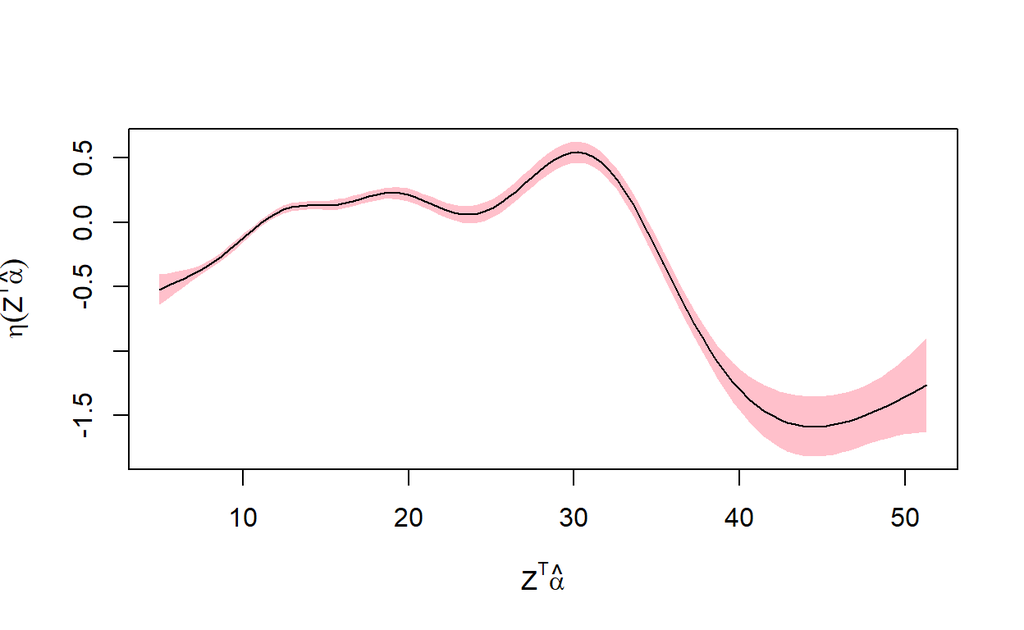

Figure 1: The estimated nonparametric function $\widehat{\eta}(\cdot)$ and associated 95% confidence bands for the wage dataset.

**Example 4** In this example we illustrate the function `plsim.est` by application to the corrected version of the Boston Housing Data of (Harrison and Rubinfeld 1978b): the corrections were made by (Gilley and Pace 1996) and the data are available in R in, e.g., the package spdep.

This study concerns the median value of owner-occupied homes for 506 census tracts of Boston from the 1970 census. The response variable is the corrected median value of owner-occupied homes in thousands of dollars (`medv`); i.e., the median prices were censored at 50.00 because the highest median price of exactly $50,000 was reported in 16 cases, while 15 cases have prices between $40,000 and $50,000, with prices rounded to the nearest hundred. Among the 13 covariates, one is a binary variable which takes value 1 if the tract borders the Charles River (`CHAS`). The continuous variables are per capita crime rate by town (`CRIM`), proportion of residential land zoned for lots over 25,000 square feet (`CN`), proportion of non-retail business acres per town (`INDUS`), nitric oxides concentration (`NOX`), average number of rooms per dwelling (`RM`), proportion of owner-occupied units built prior to 1940 (`AGE`), weighted distances to five Boston employment centres (`DIS`), index of accessibility to radial highways (`RAD`), full-value property-tax rate per 10,000 dollars (`TAX`), pupil-teacher ratio by town (`PTRATIO`), proportion of African-Americans by town (`B`), and percentage of lower status of the population (`LSTAT`). We map all continuous predictors to the interval $[0,1]$.

```r
data("BostonHousing", package = "mlbench")
y0 <- BostonHousing[, "medv"]
n <- length(y0)
y <- matrix(y0)
x0 <- as.numeric(BostonHousing[, "chas"])
x <- matrix(x0)
z0 <- BostonHousing[, setdiff(names(BostonHousing), c("chas", "medv"))]
dx <- dim(z0)[2]
dz <- dim(x)[2]
z0 <- standardize(z0)
z <- as.matrix(z0)
```

We fit a PLSiM by taking `chas` as a $X$-variable and all others as $Z$-variables. We conduct three analyses: (i) $\bf{RUN 1}$: select 80% of samples as training set and the remaining as test set, and then fit the dataset by simply including all variables in a PLSiM; (ii) $\bf{RUN 2}$: do variable selection first and then refit a PLSiM for selected variables; and (iii) $\bf{RUN 3}$: perform 3-fold cross validation to validate the effectiveness of PLSiM.

1. **RUN1**

```r
set.seed(3)
trainIdx <- sample.int(ceiling(0.8 * n), n = n)
testIdx <- setdiff(1:n, trainIdx)
x_train <- x[trainIdx, ]
x_test <- x[testIdx, ]
z_train <- z[trainIdx, ]
z_test <- z[testIdx, ]
xn <- NULL
xz_train <- cbind(x_train, z_train)
y_train <- matrix(y[trainIdx])
y_test <- matrix(y[testIdx])
fit_plsimest <- plsim.est(y_train ~ xn|xz_train,
    ParmaSelMethod = "CrossValidation", verbose = F)
fit_plsimest$data$h
```

```
[1] 0.1682
```

```r
fit_plsimest$mse
```

```
      [,1]
[1,] 11.24
```

```r
fit_plsimest$r_square
```

```
       [,1]
[1,] 0.8612
```

```r
preds_plsimest <- predict(fit_plsimest, NULL, cbind(x_test, z_test))
print(sum((preds_plsimest - y_test)^2) / nrow(y_test))
```

```
[1] 27.53
```

In this example, we {use the function} `plsim.bw` {embedded in the function} `plsim.est` from the range $[{0.1}/{\sqrt{n}}, {2\sqrt{\log{n}}}/{\sqrt{n}}]$. To explore computational efficiency, we also try the function `plsim.MAVE` with only 5 candidate bandwidths. Its running time is much longer than the function `plsim.est`. The former needs 69.9 seconds, while the latter needs only 37 seconds.

```r
hSet <- seq(fit_plsimest$data$h * 0.8, fit_plsimest$data$h * 1.2,
    length = 5)
fit_MAVE <- plsim.MAVE(y_train ~ xn|xz_train, h = hSet, verbose = F)
fit_MAVE$mse
```

```
[1] 13.45
```

```r
fit_MAVE$r_square
```

```
      [,1]
[1,] 0.834
```

```r
preds_MAVE <- predict(fit_MAVE, NULL, cbind(x_test, z_test))
print(sum((preds_MAVE - y_test)^2) / nrow(y_test))
```

```
[1] 36.61
```

Compared with `plsim.est`, the performance of `plsim.MAVE` on the test set is much worse than that of `plsim.est`. The corresponding MSEs based on `plsim.MAVE` and `plsim.est` for the training set are 13.4 and 11.2, respectively, while the corresponding MSEs based on `plsim.MAVE` and `plsim.est` for the testing set are 36.6 and 27.5, respectively.

2. **RUN2**

We try to select variables via the function `plsim.vs.hard` to alleviate overfitting. After variable selection, `plsim.est` can achieve a better performance.

```r
hSet <- seq(fit_plsimest$data$h * 0.8, fit_plsimest$data$h * 1.2,
    length = 5)

car_varSel2_SCAD <- plsim.vs.hard(y_train ~ xn|xz_train,
    verbose = F, h = hSet, ParmaSelMethod = "CrossValidation")

xz_train <- cbind(x_train, z_train)
xz_test <- cbind(x_test, z_test)
xz_train_new <- xz_train[, car_varSel2_SCAD$alpha_varSel]
fit_plsimest_vs <- plsim.est(y_train ~ xn|xz_train_new, h = hSet,
    ParmaSelMethod = "CrossValidation")
```

```
 Utilize the MAVE_ini method to initialize coefficients

 Cross Validation for Bandwidth Selection for plsimest
```

```r
fit_plsimest_vs$mse
```

```
      [,1]
[1,] 12.16
```

```r
fit_plsimest_vs$r_square
```

```
     [,1]
[1,] 0.85
```

```r
preds_plsimest_vs <- predict(fit_plsimest_vs, NULL,
    xz_test[, car_varSel2_SCAD$alpha_varSel])
print( sum( (preds_plsimest_vs-y_test)^2) / nrow(y_test) )
```

```
[1] 26.12
```

3. **RUN3**

A simple trail may not validate the effectiveness of `plsim.est` after variable selection. Therefore, we perform 3-fold cross validation to compare the performance. All variables are taken as Z-variables. In this example, we use the function `plsim.bw` embedded in the function `plsim.est` to select bandwidth ranging $[{0.1}/{\sqrt{n}}, {2\sqrt{\log{n}}}/{\sqrt{n}}]$, which is also applied to `plsim.MAVE`. The corresponding MSEs based on `plsim.MAVE` and `plsim.est` for the training set are 12.9 and 16.1.

```r
CVgroup <- function(k = 3, datasize, seed = 0){
    cvlist <- list()
    set.seed(seed)
    n <- rep(1:k, ceiling(datasize / k))[1:datasize]
    temp <- sample(n, datasize)
    x <- 1:k
    dataseq <- 1:datasize
    cvlist <- lapply(x, function(x) dataseq[temp == x])
    return(cvlist)
  }
idxList <- CVgroup(k = 3, datasize = n, seed = 42)
mse_plsimest_train <- vector(length = 3, mode = "numeric")
mse_MAVE_train <- vector(length = 3, mode = "numeric")
mse_plsimest_vs_train <- vector(length = 3, mode = "numeric")
R2_plsimest <- vector(length = 3, mode = "numeric")
R2_MAVE <- vector(length = 3, mode = "numeric")
R2_plsimest_vs <- vector(length = 3, mode = "numeric")
mse_plsimest <- vector(length = 3, mode = "numeric")
mse_MAVE <- vector(length = 3, mode = "numeric")
mse_plsimest_vs <- vector(length = 3, mode = "numeric")
for(i in 1:length(idxList))
  {
    print(i)
    testIdx <- idxList[[i]]
    trainIdx <- setdiff(1:n, testIdx)

    x_train <- x[trainIdx, ]
    x_test <- x[testIdx, ]
    z_train <- z[trainIdx, ]
    z_test <- z[testIdx, ]
    y_train <- matrix(y[trainIdx])
    y_test <- matrix(y[testIdx])
    xz_train <- cbind(x_train, z_train)
    xn = NULL
    m = length(y_train)

    fit_plsimest <- plsim.est(y_train ~ xn|xz_train, verbose = F)

    R2_plsimest[i] <- fit_plsimest$r_square
    mse_plsimest_train[i] <- fit_plsimest$mse

    preds_plsimest <- predict(fit_plsimest, NULL, cbind(x_test, z_test))
    mse_plsimest[i] <- sum((preds_plsimest - y_test)^2) / nrow(y_test)
    hSet <- seq(fit_plsimest$data$h * 0.8, fit_plsimest$data$h * 1.2,
      length = 5)
    bSet <- seq(0.1 / sqrt(m), 2 * sqrt(log(m) / m), length = 20)

    fit_MAVE <- plsim.MAVE(y_train ~ xn|xz_train, h = bSet, verbose = F)

    R2_MAVE[i] <- fit_MAVE$r_square
    mse_MAVE_train[i] <- fit_MAVE$mse

    preds_MAVE <- predict(fit_MAVE, NULL, cbind(x_test, z_test))
    mse_MAVE[i] <- sum((preds_MAVE - y_test)^2) / nrow(y_test)

    car_varSel2_SCAD <- plsim.vs.hard(y_train ~ xn|xz_train, verbose = F,
      h = hSet)

    xz_train_new <- xz_train[, car_varSel2_SCAD$alpha_varSel]
    xz_test <- cbind(x_test, z_test)

    fit_plsimest_vs <- plsim.est(y_train ~ xn|xz_train_new, h = hSet,
      verbose = F)

    R2_plsimest_vs[i] <- fit_plsimest_vs$r_square
    mse_plsimest_vs_train[i] <- fit_plsimest_vs$mse

    preds_plsimest_vs <- predict(fit_plsimest_vs, NULL,
      xz_test[, car_varSel2_SCAD$alpha_varSel])
    mse_plsimest_vs[i] <- sum((preds_plsimest_vs - y_test)^2) / nrow(y_test)
  }
```

```
[1] 1
[1] 2
[1] 3
```

```r
cat("Cross validation result of train mse: ")
```

```
Cross validation result of train mse:
```

```r
mean(mse_plsimest_train)
```

```
[1] 16.1
```

```r
mean(mse_MAVE_train)
```

```
[1] 12.9
```

```r
mean(mse_plsimest_vs_train)
```

```
[1] 13.28
```

```r
cat("Cross validation result of train R^2: ")
```

```
Cross validation result of train R^2:
```

```r
mean(R2_plsimest)
```

```
[1] 0.8078
```

```r
mean(R2_MAVE)
```

```
[1] 0.8486
```

```r
mean(R2_plsimest_vs)
```

```
[1] 0.8426
```

```r
cat("Cross validation result of test mse: ")
```

```
Cross validation result of test mse:
```

```r
mean(mse_plsimest)
```

```
[1] 25.87
```

```r
mean(mse_MAVE)
```

```
[1] 29.79
```

```r
mean(mse_plsimest_vs)
```

```
[1] 21.73
```

Table 1: The comparison results of $R^2$, MSE and the MSE with the testing, computation time based on the profile estimation (PLSiM), MAVE, and penalized profile estimation (PLSiM(vs)).

|  | R^2 | MSE | MSE(test) | Time |
| --- | --- | --- | --- | --- |
| PLSiM | 0.808 | 16.1 | 25.9 | 100.8 |
| PLSiM(vs) | 0.843 | 13.3 | 21.7 | 562.9 |
| MAVE | 0.849 | 12.9 | 29.8 | 1354.1 |

These outputs are summarized in Table 1. Compared with `plsim.est`, the fitting effect of `plsim.MAVE` is slightly better in terms of their and $R^2$ values. However, the performance of `plsim.MAVE` on the test set is much worse than that of `plsim.est`. This may be owing to overfitting. Additionally, `mean(mse_plsimest_vs)` is remarkably smaller than that of `mean(mse_plsimest)`, which demonstrates the superiority of variable selection.

# Discussions and conclusions

In this paper, we introduce the **R** package PLSiMCpp, which we have developed for partially linear single-index models. The package was interfaced with **C++**, and making implementation very expedient for estimation, hypothesis and variable selection procedure. The package can apply only for continuous response variable. Remarkable efforts are needed for extending to discrete response variable, which we will work on.

Bandwidth plays a critical role in the estimation, hypothesis and variable selection. We have adopted a data-driven strategy for selecting bandwidth. But this is a global bandwidth (i.e., a constant) selection. Ideally, a local bandwidth (i.e., varying bandwidths) selection should be more realistic and useful, yet the computation cost may increase.

# Acknowledgments

Wu’s research was partially supported by National Natural Science Foundation of China (No. 41706198, No. 61673228 and No. 11871294), Shandong Provincial Natural Science Foundation, China (No. ZR2019PF012) and A Project of Shandong Province Higher Educational Science and Technology Program (No. J18KA356). Zhang’s research was partially supported by National Natural Science Foundation of China (No. 11701318 and No. 11871294) and Shandong Provincial Natural Science Foundation, China (No. ZR2017MF055).

## CRAN packages used

PLSiMCpp, mgcv, KernSmooth, lokern, sm, spdep

## CRAN Task Views implied by cited packages

Bayesian, Econometrics, Environmetrics, Spatial

A. Bowman and A. Azzalini. *Sm: Smoothing methods for nonparametric regression and density estimation.* 2018. R package version 2.2-5.6.

R. J. Carroll, J. Fan, I. Gijbels and M. P. Wand. Generalized partially linear single-index models. *Journal of the American Statistical Association*, 92(438): 477–489, 1997.

N. Duan and K.-C. Li. Slicing regression: A link-free regression method. *The Annals of Statistics*, 19: 505–530, 1991.

J. Fan and I. Gijbels. Data-driven bandwidth selection in local polynomial fitting: Variable bandwidth and spatial adaptation. *Journal of the Royal Statistical Society, Series B*, 57: 371–394, 1995.

J. Fan and R. Li. Variable selection via nonconcave penalized likelihood and its oracle properties. *Journal of the American Statistical Association*, 96: 1348–1360, 2001.

O. W. Gilley and R. K. Pace. On the harrison and rubinfeld data. *Journal of Environmental Economics and Management*, 31: 403–405, 1996.

W. Härdle, P. Hall and H. Ichimura. Optimal smoothing in single-index models. *The Annals of Statistics*, 21: 157–178, 1993.

W. Härdle, H. Liang and J. T. Gao. *Partially linear models.* Heidelberg: Springer Physica, 2000.

D. Harrison and D. L. Rubinfeld. Hedonic prices and the demand for clean air. *Journal of Environmental Economics and Management*, 5: 81–102, 1978a.

D. Harrison and D. L. Rubinfeld. Hedonic prices and the demand for clean air. *Journal of Environmental Economics and Management*, 5: 81–102, 1978b.

E. Herrmann and M. Maechler. *Lokern: Kernel regression smoothing with local or global plug-in bandwidth.* 2019. R package version 1.1-8.

J. L. Horowitz. *Semiparametric and nonparametric methods in econometrics.* New York: Springer, 2009.

J. L. Horowitz and W. Härdle. Direct semiparametric estimation of single-index models with discrete covariates. *Journal of the American Statistical Association*, 91(436): 1632–1640, 1996.

H. Ichimura. Semiparametric least squares (SLS) and weighted SLS estimation of single-index models. *Journal of Econometrics*, 58: 71–120, 1993.

R. I. Jennrich. Asymptotic properties of non-linear least squares estimators. *Annals of Mathematical Statistics*, 40: 633–643, 1969.

H. Liang, X. Liu, R. Li and C. L. Tsai. Estimation and testing for partially linear single-index models. *The Annals of Statistics*, 38: 3811–3836, 2010.

J. L. Powell, J. H. Stock and T. M. Stoker. Semiparametric estimation of index coefficients. *Econometrica*, 57(6): 1403–1430, 1989.

T. A. Severini and W. H. Wong. Profile likelihood and conditionally parametric models. *The Annals of Statistics*, 20(4): 1768–1802, 1992.

P. Speckman. Kernel smoothing in partial linear models. *Journal of the Royal Statistical Society. Series B*, 50: 413–436, 1988.

R. Tibshirani. Regression shrinkage and selection via the lasso. *Journal of the Royal Statistical Society, Series B*, 58: 267–288, 1996.

M. Wand, C. Moler and B. Ripley. *KernSmooth: Functions for kernel smoothing.* 2019. R package version 2.23-16.

S. Wood. *Mgcv: Mixed GAM computation vehicle with automatic smoothness estimation.* 2019. R package version 1.8-29.

D. M. Wooldridge. *Introductory econometrics.* Thompson South-Western, 2003.

Y. C. Xia and W. Härdle. Semi-parametric estimation of partially linear single-index models. *Journal of Multivariate Analysis*, 97: 1162–1184, 2006.

Y. Xia, H. Tong and W. K. Li. On extended partially linear single-index models. *Biometrika*, 86: 831–842, 1999.

Y. Xia, H. Tong, W. K. Li and L.-X. Zhu. An adaptive estimation of dimension reduction space. *Journal of the Royal Statistical Society, Series B*, 64: 363–410, 2002.

Y. Yu and D. Ruppert. Penalized spline estimation for partially linear single-index models. *Journal of the American Statistical Association*, 97: 1042–1054, 2002.